# Problems with Peaks

# Background

When testing bio-mechanical specimens the first few loading cycles are often different from the stable long-term behaviour, usually due to bedding in to the fixture. It is common to reject these and only analyse the results from subsequent cycles.

Bluehill is can write a cycle and segment label to RawData files that could be used to select a particular cycle of a multi-cycle test. Unfortunately the labels are often wrong, and can lag the actual start of a cycle by quite a bit. This leads to turning points being included in the wrong cycle and makes analysis very difficult.

The solution to this issue is to find the turning points with R and segment the data using those. R lacks a standard method for finding peaks from a data series. There have been several proposed solutions to this, but in testing on test data from Bluehill they all have limitations.

## prior art

### using `max.col()`

The earliest peaks code I can find (and the most robust) appears to be due to Brian Ripley (one of the authors of `embed`). This is the 2001 version by Petr Pikal, after Brian Ripley, quoted in https://stat.ethz.ch/pipermail/r-help/2005-November/083240.html

```r
peaks1 <- function(series, span=3) {
  z <- embed(series, span)
  result <- max.col(z) == 1 + span %/% 2
  result
}
```

This function works by taking creating a matrix where each column is the original series shifted by one. Each row of the matrix z consists of `series[i - 0], series[i - 1], ... series[i - span+1]`. `max.col()` then returns the number of the column with the biggest value, so `result` will be `TRUE` when the biggest value is in column `(1 + span %/% 2)`, i.e. when the middle column is bigger. The columns are all shifted by 1, so the columns to the left will be the previous `span %/% 2` points and the columns on the right will be the next `span %/% 2` points. If the middle column is bigger than that point is bigger than it’s `span %/% 2` neighbours on either side. In other words, a peak. The `result` vector returned by this function will be shorted than the original series, losing `peak %/%2` points from either end as the input series is shifted off the end.

The next function uses the same idea, extended by Petr Pikal to pad `result` to the same length as the input `series`.

```r
peaks2<-function(series,span=3) {
  z <- embed(series, span)
  s <- span%/%2
  v<- max.col(z) == 1 + s
  result <- c(rep(FALSE,s),v)
  result <- result[1:(length(result)-s)]
  result
}
```

### using equalities

Both of these functions were cited on r-help in November 2005 r-help. Later in the thread Martin Maechler (maechler@stat.math.ethz.ch) presented a different idea. https://stat.ethz.ch/pipermail/r-help/2005-November/083376.html

```r
peaks3 <- function(series, span = 3, do.pad = TRUE) {
  if ((span <- as.integer(span)) %% 2 != 1) stop("'span' must be odd")
  s1 <- 1:1 + (s <- span %/% 2)
  if (span == 1) return(rep.int(TRUE, length(series)))
  z <- stats::embed(series, span)
  v <- apply(z[, s1] > z[, -s1, drop = FALSE], 1, all)
  if (do.pad) {
    pad <- rep.int(FALSE, s)
    c(pad, v, pad)
  } else v
}
```

This function uses `embed()` like the previous functions, but then instead of calling `max.col()` it builds a matrix of tests if column `s1` is greater than each column except `s1`. Then it checks if all columns in each row are `TRUE`. It this is the case, then column `s` must be bigger than all the other columns, so that point must be a peak. The output vector is finally padded to the imput length, if requested. Note that is uses the to my eye odd idiom of adding a sequence `1:1` to `span %/% 2` rather than just adding an integer. This may be something common in R, but I have’t seen it elsewhere.

Maechler’s approach has the advantage that it can be extended to find troughs, where column `s1` is less than all other columns. Maechler also provides this function:

```r
peaksign <- function(series, span = 3, do.pad = TRUE) {
  ## Purpose: return (-1 / 0 / 1) if series[i] is ( trough / "normal" / peak )
  ## ----------------------------------------------------------------------
  ## Author: Martin Maechler, Date: 25 Nov 2005
  if ((span <- as.integer(span)) %% 2 != 1 || span == 1)
    stop("'span' must be odd and >= 3")
  s1 <- 1:1 + (s <- span %/% 2)
  z <- stats::embed(series, span)
  d <- z[, s1] - z[, -s1, drop = FALSE]
  ans <- rep.int(0:0, nrow(d))
  ans[apply(d > 0, 1, all)] <- as.integer(1)
  ans[apply(d < 0, 1, all)] <- as.integer(-1)
  if (do.pad) {
    pad <- rep.int(0:0, s)
    c(pad, ans, pad)
  } else ans
}
```

Both of these functions have a problem with ties, where a peak has several consecutive points all at the same value. In this case they will fail to find the peak as the points on either side are not strictly greater or less than the “peak” point.

This problem can be addressed by making one of the inequalities `>=` (or `<=` depending on which is chosen). For peaks alone:

```
  z <- stats::embed(series, span)
  v <- apply(z[, s1] >= z[, -s1, drop = FALSE], 1, all)
```

And for peaks & troughs:

```
  z <- stats::embed(series, span)
  d <- z[, s1] - z[, -s1, drop = FALSE]
  ans <- rep.int(0:0, nrow(d))
  ans[apply(d >= 0, 1, all)] <- as.integer(1)
  ans[apply(d < 0,  1, all)] <- as.integer(-1)
```

This approach detects peaks with repeated values, but will return runs of `TRUE` for each point in the peak. The modified `peaksign` will return runs of `+1` or `-1`.

Using `max.col()` avoids this as it will only return one value if there are ties. The value is decided by the parameter `ties.method = c("random", "first", "last")`. The default is `random`, which Ripley prefers, as in a flat spot no single point could really be called the peak. The drawback of using `random` is that the chosen peak point can vary between runs of the code, which is inconvenient.

## My solution

Finding both peaks and troughs is very convenient for the sort of cyclic data produced by mechanical testing. I considered two approaches:

1. using `peaksign` and reducing runs of peaks to a single point
2. using `max.col()` to detect peaks and troughs

Unfortunately there is no `min.col()`, but `max.col(-z)` achieves the same effect. As `max.col()` is written in C it is very fast so calling it twice should not be a big performance hit. This approach seemed easier and cleaner than detecting and reducing runs in the Maechler version of `peaksigns`. I have kept Maechler’s idea of using the logical vector `max.col() == middle` to select where to insert `1L` or `-1L` into a vector of zeros.

```r
#' Find Peaks and Troughs 2
#'
#' My version, starting from Brian Ripley's and informed by all the others
#' @param series the vector of numbers to find peaks in.
#' @param span the window size to use when looking for lower values.
#' @return a logical vector, TRUE for each peak
#'
peaksign2 <- function(series, span=3, do.pad = TRUE) {
  if ((span <- as.integer(span)) %% 2 != 1 || span == 1) {
    stop("'span' must be odd and >= 3")
  }
  z <- stats::embed(series, span)
  s <- span %/% 2
  ans <- rep.int(0L, nrow(z))
  # max is peak
  v <- max.col(z, ties.method = "first")  == (1 + s)
  ans[v] <-  1
  # no min.col so uses max(-v) for trough
  v <- max.col(-z, ties.method = "first")  == (1 + s)
  ans[v] <- -1
  if (do.pad) {
    pad <- rep.int(0L, s)
    c(pad, ans, pad)
  } else {
    ans
  }
}
```

This final version handles flat peaks with multiple identical values, and detects both peaks and troughs in a single function.

## Timing

How do the various versions compare? Using `microbenchmark` and real sample data that has a “flat” peak in 8800:9200 (second peak)

```r
library(data.table)
# NB - need to set knitr to use the Project Directory
print(getwd())
```

```
[1] "/Users/Brenna/Documents/BEG15.008"
```

```r
test.file <- "./inst/extdata/vero_clear.is_ccyclic_RawData/Specimen_RawData_6.csv"
DT <- fread (test.file, skip = 5, col.names = c("time", "ext", "load"), select = 1:3)
DT[, ext := - ext] # need to invert as is compression test
DT[, load := -load]
library(microbenchmark)
mbm <- microbenchmark(
  ripley   = p1 <- DT[, peaks1(ext)],
  pikal    = p2 <- DT[, peaks2(ext)],
  maechler = p3 <- DT[, peaks3(ext)],
  peaksign = ps <- DT[, peaksign(ext)],
  mine     = me <- DT[, peaksign2(ext)]
)
print(mbm)
```

```
Unit: milliseconds
```

| expr | min | lq | mean | median | uq | max | neval |
| --- | --- | --- | --- | --- | --- | --- | --- |
| ripley | 2.520803 | 3.269232 | 3.730232 | 3.500151 | 3.708238 | 15.60308 | 100 |
| pikal | 2.890119 | 3.416475 | 3.952747 | 3.676760 | 4.006538 | 19.52774 | 100 |
| maechler | 43.195490 | 46.259513 | 52.063580 | 48.969482 | 51.927288 | 93.67463 | 100 |
| peaksign | 84.945089 | 90.468998 | 97.278729 | 93.644781 | 97.966636 | 164.44194 | 100 |
| mine | 3.533658 | 4.605156 | 5.454993 | 4.803523 | 5.613535 | 36.42737 | 100 |

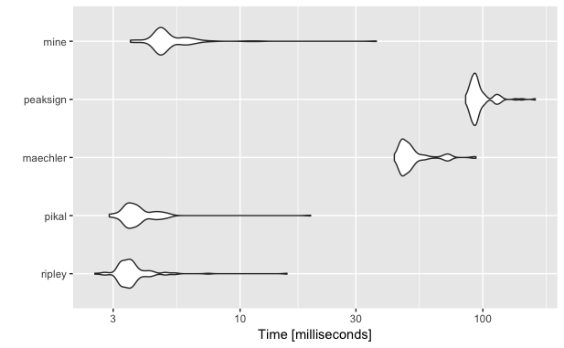

```r
library(ggplot2)
ggplot2::autoplot(mbm)
```

What peaks did each method find? There should be three peaks and two troughs, with the beginning end of the series being virtual troughs. By inspection the peaks should be near 3000, 9000, 15000 and the troughs near 6000, 12000.

| type |  |  |  |  |  |
| --- | --- | --- | --- | --- | --- |
| peaks | `2900:3100` |  | `8800:9200` |  | `14900:15100` |
| troughs |  | `5900:6100` |  | `11900:12100` |  |

Peaks only

- ripley 3004, 9006, 15009
- pikal 3005, 9007, 9008, 15010
- macheler 3005, 15010

Peaks and troughs

- macheler 3005, 15010
- mine 3005, 9008, 15010
- macheler 6006, 12009
- mine 2, 6006, 12009
- ripley 1, 6005, 12008